# ridge_lasso

### Sample notebook for multiple linear regression (MLR) for Abalone data

アワビデータの重回帰分析の手順例

Sex / nominal / -- / M, F, and I (infant)  
Length / continuous / mm / Longest shell measurement  
Diameter / continuous / mm / perpendicular to length  
Height / continuous / mm / with meat in shell  
Whole weight / continuous / grams / whole abalone  
Shucked weight / continuous / grams / weight of meat  
Viscera weight / continuous / grams / gut weight (after bleeding)  
Shell weight / continuous / grams / after being dried  
Rings / integer / -- / +1.5 gives the age in years

#### Import libraries

```python
import sys
import numpy as np
import pandas as pd
from pandas.plotting import scatter_matrix
import seaborn as sns
import matplotlib
import matplotlib.pyplot as plt
from pandas.plotting import register_matplotlib_converters
register_matplotlib_converters()
from sklearn import preprocessing
import statsmodels.api as sm
import statsmodels.formula.api as smf
```

#### Parameters

```python
%config InlineBackend.figure_formats = {'png', 'retina'} #high-reso images
font = {'family' : 'Yu Mincho'}
matplotlib.rc('font', **font)

# To show all rows and columns in the results
pd.options.display.max_rows = 999
pd.options.display.max_columns = 999
```

#### Step 1. Collect possible explanatory variables

目的変数に影響を与えていそうな要因は、可能な限り網羅的に説明変数に取り入れる。

##### Check & read CSV file, replace column labels if needed, etc.

encoding='shift-jis' may be needed.  
CSVファイルをチェックしてから読み込む。必要に応じて列ラベルを変更。  
CSVファイルの漢字コードがShift-JISの場合は encoding='shift-jis' が必要。

```python
csv_in = 'abalone_modified.csv'
df_all = pd.read_csv(csv_in, delimiter=',', skiprows=0, header=None)
# no header in csv, so set columns explicitly
df_all.columns = ['sex', 'len', 'd', 'h', 'w_all', 'w_meat', 'w_gut', 'w_shell', 'ring']
print(df_all.shape)
print(df_all.info())
display(df_all.head())
```

```
(4177, 9)
<class 'pandas.core.frame.DataFrame'>
RangeIndex: 4177 entries, 0 to 4176
Data columns (total 9 columns):
sex        4177 non-null object
len        4177 non-null float64
d          4177 non-null float64
h          4177 non-null float64
w_all      4177 non-null float64
w_meat     4177 non-null float64
w_gut      4177 non-null float64
w_shell    4177 non-null float64
ring       4177 non-null int64
dtypes: float64(7), int64(1), object(1)
memory usage: 293.8+ KB
None
```

|  | sex | len | d | h | w_all | w_meat | w_gut | w_shell | ring |
| --- | --- | --- | --- | --- | --- | --- | --- | --- | --- |
| 0 | M | 0.455 | 0.365 | 0.095 | 0.5140 | 0.2245 | 0.1010 | 0.150 | 15 |
| 1 | M | 0.350 | 0.265 | 0.090 | 0.2255 | 0.0995 | 0.0485 | 0.070 | 7 |
| 2 | F | 0.530 | 0.420 | 0.135 | 0.6770 | 0.2565 | 0.1415 | 0.210 | 9 |
| 3 | M | 0.440 | 0.365 | 0.125 | 0.5160 | 0.2155 | 0.1140 | 0.155 | 10 |
| 4 | I | 0.330 | 0.255 | 0.080 | 0.2050 | 0.0895 | 0.0395 | 0.055 | 7 |

##### Check numerical / category variables if needed

数値列・カテゴリー列の様子をみる

```python
display(df_all.describe())
display(df_all.describe(exclude='number'))
```

|  | len | d | h | w_all | w_meat | w_gut | w_shell | ring |
| --- | --- | --- | --- | --- | --- | --- | --- | --- |
| count | 4177.000000 | 4177.000000 | 4177.000000 | 4177.000000 | 4177.000000 | 4177.000000 | 4177.000000 | 4177.000000 |
| mean | 0.523992 | 0.407881 | 0.139516 | 0.828742 | 0.359367 | 0.180594 | 0.238831 | 9.933684 |
| std | 0.120093 | 0.099240 | 0.041827 | 0.490389 | 0.221963 | 0.109614 | 0.139203 | 3.224169 |
| min | 0.075000 | 0.055000 | 0.000000 | 0.002000 | 0.001000 | 0.000500 | 0.001500 | 1.000000 |
| 25% | 0.450000 | 0.350000 | 0.115000 | 0.441500 | 0.186000 | 0.093500 | 0.130000 | 8.000000 |
| 50% | 0.545000 | 0.425000 | 0.140000 | 0.799500 | 0.336000 | 0.171000 | 0.234000 | 9.000000 |
| 75% | 0.615000 | 0.480000 | 0.165000 | 1.153000 | 0.502000 | 0.253000 | 0.329000 | 11.000000 |
| max | 0.815000 | 0.650000 | 1.130000 | 2.825500 | 1.488000 | 0.760000 | 1.005000 | 29.000000 |

|  | sex |
| --- | --- |
| count | 4177 |
| unique | 3 |
| top | M |
| freq | 1528 |

##### See rows including missing data

欠損値を含む行を表示してみる

```python
display(df_all[df_all.isnull().any(axis=1)])
```

|  | sex | len | d | h | w_all | w_meat | w_gut | w_shell | ring |
| --- | --- | --- | --- | --- | --- | --- | --- | --- | --- |

##### Delete rows including missing data, or fill missing data

欠損値を含む行を削除する (または欠損値を埋める)

```python
df_all = df_all.dropna().reset_index(drop=True)
#df_all = df_all.fillna(df_all.mean()) # if you want to fill missing data instead of deleting them
print(df_all.shape)
display(df_all.head())
```

```
(4177, 9)
```

|  | sex | len | d | h | w_all | w_meat | w_gut | w_shell | ring |
| --- | --- | --- | --- | --- | --- | --- | --- | --- | --- |
| 0 | M | 0.455 | 0.365 | 0.095 | 0.5140 | 0.2245 | 0.1010 | 0.150 | 15 |
| 1 | M | 0.350 | 0.265 | 0.090 | 0.2255 | 0.0995 | 0.0485 | 0.070 | 7 |
| 2 | F | 0.530 | 0.420 | 0.135 | 0.6770 | 0.2565 | 0.1415 | 0.210 | 9 |
| 3 | M | 0.440 | 0.365 | 0.125 | 0.5160 | 0.2155 | 0.1140 | 0.155 | 10 |
| 4 | I | 0.330 | 0.255 | 0.080 | 0.2050 | 0.0895 | 0.0395 | 0.055 | 7 |

##### Separate explanatory variables and objective variable

説明変数と目的変数を分ける

```python
X_all_org = df_all.loc[:, 'sex':'w_shell']  # explanatory variables
y = df_all['ring']  # objective variable
print('X_all_org:', X_all_org.shape)
display(X_all_org.head())
print('y:', y.shape)
print(y.head())
```

```
X_all_org: (4177, 8)
```

|  | sex | len | d | h | w_all | w_meat | w_gut | w_shell |
| --- | --- | --- | --- | --- | --- | --- | --- | --- |
| 0 | M | 0.455 | 0.365 | 0.095 | 0.5140 | 0.2245 | 0.1010 | 0.150 |
| 1 | M | 0.350 | 0.265 | 0.090 | 0.2255 | 0.0995 | 0.0485 | 0.070 |
| 2 | F | 0.530 | 0.420 | 0.135 | 0.6770 | 0.2565 | 0.1415 | 0.210 |
| 3 | M | 0.440 | 0.365 | 0.125 | 0.5160 | 0.2155 | 0.1140 | 0.155 |
| 4 | I | 0.330 | 0.255 | 0.080 | 0.2050 | 0.0895 | 0.0395 | 0.055 |

```
y: (4177,)
0    15
1     7
2     9
3    10
4     7
Name: ring, dtype: int64
```

##### Apply get_dummies()

ダミー変数化

```python
X_all = pd.get_dummies(X_all_org, drop_first=True)
print('X_all:', X_all.shape)
display(X_all.head())
```

```
X_all: (4177, 9)
```

|  | len | d | h | w_all | w_meat | w_gut | w_shell | sex_I | sex_M |
| --- | --- | --- | --- | --- | --- | --- | --- | --- | --- |
| 0 | 0.455 | 0.365 | 0.095 | 0.5140 | 0.2245 | 0.1010 | 0.150 | 0 | 1 |
| 1 | 0.350 | 0.265 | 0.090 | 0.2255 | 0.0995 | 0.0485 | 0.070 | 0 | 1 |
| 2 | 0.530 | 0.420 | 0.135 | 0.6770 | 0.2565 | 0.1415 | 0.210 | 0 | 0 |
| 3 | 0.440 | 0.365 | 0.125 | 0.5160 | 0.2155 | 0.1140 | 0.155 | 0 | 1 |
| 4 | 0.330 | 0.255 | 0.080 | 0.2050 | 0.0895 | 0.0395 | 0.055 | 1 | 0 |

#### Step 2. Scatter plot and correlation coefficients between all combination of explanatory variables

変数間の総当たり散布図を描画。相関係数も算出しておく

##### all by all Pearson correlation coefficients;

総当たりのPearson相関係数

```python
corr_all = X_all.corr(method='pearson')
display(corr_all)
```

|  | len | d | h | w_all | w_meat | w_gut | w_shell | sex_I | sex_M |
| --- | --- | --- | --- | --- | --- | --- | --- | --- | --- |
| len | 1.000000 | 0.986812 | 0.827554 | 0.925261 | 0.897914 | 0.903018 | 0.897706 | -0.551465 | 0.236543 |
| d | 0.986812 | 1.000000 | 0.833684 | 0.925452 | 0.893162 | 0.899724 | 0.905330 | -0.564315 | 0.240376 |
| h | 0.827554 | 0.833684 | 1.000000 | 0.819221 | 0.774972 | 0.798319 | 0.817338 | -0.518552 | 0.215459 |
| w_all | 0.925261 | 0.925452 | 0.819221 | 1.000000 | 0.969405 | 0.966375 | 0.955355 | -0.557592 | 0.252038 |
| w_meat | 0.897914 | 0.893162 | 0.774972 | 0.969405 | 1.000000 | 0.931961 | 0.882617 | -0.521842 | 0.251793 |
| w_gut | 0.903018 | 0.899724 | 0.798319 | 0.966375 | 0.931961 | 1.000000 | 0.907656 | -0.556081 | 0.242194 |
| w_shell | 0.897706 | 0.905330 | 0.817338 | 0.955355 | 0.882617 | 0.907656 | 1.000000 | -0.546953 | 0.235391 |
| sex_I | -0.551465 | -0.564315 | -0.518552 | -0.557592 | -0.521842 | -0.556081 | -0.546953 | 1.000000 | -0.522541 |
| sex_M | 0.236543 | 0.240376 | 0.215459 | 0.252038 | 0.251793 | 0.242194 | 0.235391 | -0.522541 | 1.000000 |

##### Pickup explanatory variable pairs with large absolute value of correlation coefficient;

相関係数の絶対値が大きい説明変数ペアの出力

```python
th_corr = 0.3
keep = np.triu(np.ones(corr_all.shape), k=1).astype('bool').flatten()
triu = corr_all.stack()[keep]
triu_sorted = triu[ np.abs(triu).sort_values(ascending=False).index ]
print(triu_sorted[ (triu_sorted < -th_corr) | (triu_sorted > th_corr) ])
```

```
len      d          0.986812
w_all    w_meat     0.969405
         w_gut      0.966375
         w_shell    0.955355
w_meat   w_gut      0.931961
d        w_all      0.925452
len      w_all      0.925261
w_gut    w_shell    0.907656
d        w_shell    0.905330
len      w_gut      0.903018
d        w_gut      0.899724
len      w_meat     0.897914
         w_shell    0.897706
d        w_meat     0.893162
w_meat   w_shell    0.882617
d        h          0.833684
len      h          0.827554
h        w_all      0.819221
         w_shell    0.817338
         w_gut      0.798319
         w_meat     0.774972
d        sex_I     -0.564315
w_all    sex_I     -0.557592
w_gut    sex_I     -0.556081
len      sex_I     -0.551465
w_shell  sex_I     -0.546953
sex_I    sex_M     -0.522541
w_meat   sex_I     -0.521842
h        sex_I     -0.518552
dtype: float64
```

##### all by all scatter plots of explanatory variables;

変数間の総当たり散布図

##### if you want to use seaborn instead of matplotlib

seabornを使うなら

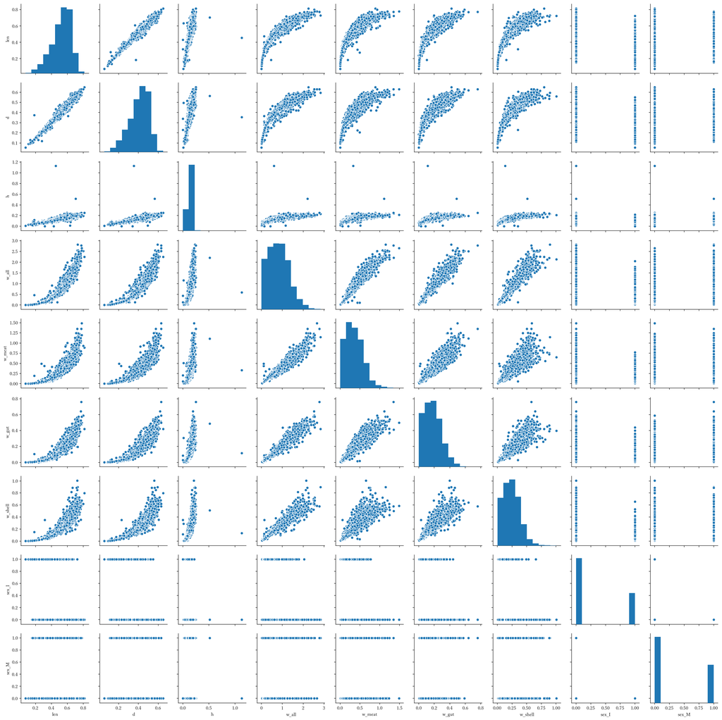

```python
sns.pairplot(X_all)
plt.show()
```

##### Heatmap

Heatmapを描いてもよい

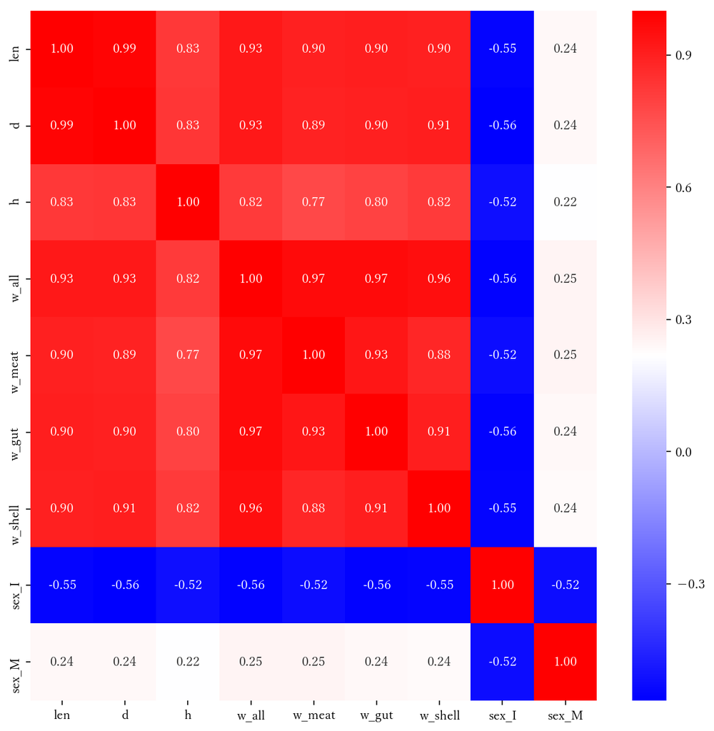

```python
plt.figure(figsize=(10,10))
sns.heatmap(corr_all,annot=True,fmt='.2f',cmap='bwr')
plt.show()
```

#### Step 3. MLR calculation using all variables

全説明変数を用いて、標準化なしで線形重回帰分析

```python
X_all_c = sm.add_constant(X_all)
model = sm.OLS(y, X_all_c)
results = model.fit()
print(results.summary())
```

```
                            OLS Regression Results
==============================================================================
Dep. Variable:                   ring   R-squared:                       0.538
Model:                            OLS   Adj. R-squared:                  0.537
Method:                 Least Squares   F-statistic:                     538.9
Date:                Tue, 23 Apr 2019   Prob (F-statistic):               0.00
Time:                        20:25:56   Log-Likelihood:                -9204.1
No. Observations:                4177   AIC:                         1.843e+04
Df Residuals:                    4167   BIC:                         1.849e+04
Df Model:                           9
Covariance Type:            nonrobust
==============================================================================
                 coef    std err          t      P>|t|      [0.025      0.975]
------------------------------------------------------------------------------
const          3.8946      0.292     13.358      0.000       3.323       4.466
len           -0.4583      1.809     -0.253      0.800      -4.005       3.089
d             11.0751      2.227      4.972      0.000       6.708      15.442
h             10.7615      1.536      7.005      0.000       7.750      13.773
w_all          8.9754      0.725     12.373      0.000       7.553      10.398
w_meat       -19.7869      0.817    -24.209      0.000     -21.389     -18.184
w_gut        -10.5818      1.294     -8.179      0.000     -13.118      -8.045
w_shell        8.7418      1.125      7.772      0.000       6.537      10.947
sex_I         -0.8249      0.102     -8.056      0.000      -1.026      -0.624
sex_M          0.0577      0.083      0.692      0.489      -0.106       0.221
==============================================================================
Omnibus:                      947.032   Durbin-Watson:                   1.436
Prob(Omnibus):                  0.000   Jarque-Bera (JB):             2710.271
Skew:                           1.181   Prob(JB):                         0.00
Kurtosis:                       6.162   Cond. No.                         137.
==============================================================================

Warnings:
[1] Standard Errors assume that the covariance matrix of the errors is correctly specified.
```

#### Step 4. Check R2 and Adjusted R2 to see whether MLR is appropriate for this data

決定係数や自由度調整済み決定係数をみて、そもそも線形モデルの当てはめが妥当かどうかを判断

```python
print('R2:', results.rsquared)
print('Adj R2:', results.rsquared_adj)
```

```
R2: 0.5378844030211949
Adj R2: 0.5368863131789081
```

Not bad, but not good...

#### Step 5. Stat. test for MLR equation

重回帰式の検定 (求めた重回帰式は目的変数を説明している？)

```python
print('p-values (F-statistic)', results.f_pvalue)
```

```
p-values (F-statistic) 0.0
```

Very small p-value, so this MLR equation is considered to be significant.

#### Step 6-1. Standardization of variables

全説明変数と目的変数を標準化

```python
# NOTE: after scaling, X_scaled and Y_scaled are ndarray, not DataFrame.
X_scaled = preprocessing.scale(X_all)
dfX_scaled = pd.DataFrame(X_scaled, columns=X_all.columns)
y_scaled = preprocessing.scale(y)
dfy_scaled = pd.Series(y_scaled, name=y.name)
model = sm.OLS(dfy_scaled, dfX_scaled)
```

#### Step 6-1. Ridge regression

**Ridge回帰**

```python
results_ridge = model.fit_regularized(L1_wt=0.0, alpha=0.1)
print(results_ridge.params)
```

```
[ 8.70104806e-02  1.70183449e-01  1.65917947e-01  9.27750936e-02
 -4.20694174e-01 -5.53201304e-02  4.72807017e-01 -1.32755966e-01
 -1.17494375e-04]
```

#### Step 6-2. LASSO regression

**LASSO回帰**

```python
results_lasso = model.fit_regularized(L1_wt=1.0, alpha=0.1)
print(results_lasso.params)
```

```
len        0.000000
d          0.000000
h          0.065958
w_all      0.000000
w_meat     0.000000
w_gut      0.000000
w_shell    0.440271
sex_I     -0.061053
sex_M      0.000000
dtype: float64
```

#### Step 6-3. Elastic Net regression

**Elastic Net**

```python
results_elastic = model.fit_regularized(L1_wt=0.5, alpha=0.1)
print(results_elastic.params)
```

```
len        0.000000
d          0.071059
h          0.123927
w_all      0.000000
w_meat    -0.133138
w_gut      0.000000
w_shell    0.452930
sex_I     -0.098521
sex_M      0.000000
dtype: float64
```

#### Step 7. Path plot to see which explanatory variables have large coefficients according to alpha

Explanatory variables with coefficients far from 0 have larger effect on objective variable.  
alpha値を変化させたときのどの説明変数の係数が大きいかを調べる。  
alphaを大きくしても係数が0にならない説明変数は目的変数への重要度が大きいと判断できる。

```python
alphas = 10 ** np.linspace(-3, 3, num=50)
print(alphas)
```

```
[1.00000000e-03 1.32571137e-03 1.75751062e-03 2.32995181e-03
 3.08884360e-03 4.09491506e-03 5.42867544e-03 7.19685673e-03
 9.54095476e-03 1.26485522e-02 1.67683294e-02 2.22299648e-02
 2.94705170e-02 3.90693994e-02 5.17947468e-02 6.86648845e-02
 9.10298178e-02 1.20679264e-01 1.59985872e-01 2.12095089e-01
 2.81176870e-01 3.72759372e-01 4.94171336e-01 6.55128557e-01
 8.68511374e-01 1.15139540e+00 1.52641797e+00 2.02358965e+00
 2.68269580e+00 3.55648031e+00 4.71486636e+00 6.25055193e+00
 8.28642773e+00 1.09854114e+01 1.45634848e+01 1.93069773e+01
 2.55954792e+01 3.39322177e+01 4.49843267e+01 5.96362332e+01
 7.90604321e+01 1.04811313e+02 1.38949549e+02 1.84206997e+02
 2.44205309e+02 3.23745754e+02 4.29193426e+02 5.68986603e+02
 7.54312006e+02 1.00000000e+03]
```

##### Ridge

|  | len | d | h | w_all | w_meat | w_gut | w_shell | sex_I | sex_M |
| --- | --- | --- | --- | --- | --- | --- | --- | --- | --- |
| 0.001000 | -0.009753 | 0.330688 | 0.140641 | 1.184719 | -1.275913 | -0.318012 | 0.436502 | -0.120862 | 0.008126 |
| 0.001326 | -0.007495 | 0.327603 | 0.140964 | 1.135737 | -1.252121 | -0.306725 | 0.452211 | -0.121254 | 0.007980 |
| 0.001758 | -0.004601 | 0.323681 | 0.141383 | 1.076665 | -1.223166 | -0.293143 | 0.470923 | -0.121738 | 0.007795 |
| 0.002330 | -0.000939 | 0.318759 | 0.141925 | 1.007130 | -1.188659 | -0.277201 | 0.492565 | -0.122327 | 0.007565 |
| 0.003089 | 0.003618 | 0.312682 | 0.142619 | 0.927583 | -1.148506 | -0.259032 | 0.516708 | -0.123030 | 0.007282 |

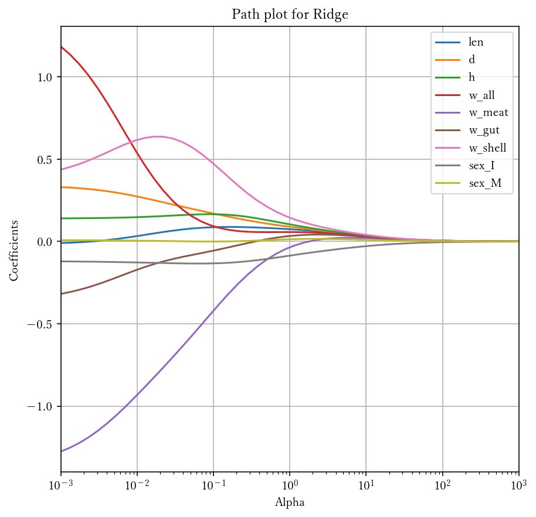

```python
ret = []
for al in alphas:
    r = model.fit_regularized(L1_wt=0.0, alpha=al)
    ret.append(r.params)

df_ret = pd.DataFrame(ret, columns=dfX_scaled.columns, index=alphas)
display(df_ret.head())  # debug
df_ret.plot(figsize=(7,7))
plt.title('Path plot for Ridge')
plt.xlabel('Alpha')
plt.ylabel('Coefficients')
plt.xscale("log")
plt.grid(True)
```

##### LASSO

|  | len | d | h | w_all | w_meat | w_gut | w_shell | sex_I | sex_M |
| --- | --- | --- | --- | --- | --- | --- | --- | --- | --- |
| 0.001000 | 0.094045 | 0.273445 | 0.143652 | 0.243461 | -0.932144 | -0.097071 | 0.784150 | -0.130166 | 0.0 |
| 0.001326 | 0.089702 | 0.273783 | 0.143408 | 0.249104 | -0.929546 | -0.094907 | 0.778223 | -0.129708 | 0.0 |
| 0.001758 | 0.083893 | 0.274248 | 0.143064 | 0.255282 | -0.925659 | -0.091623 | 0.770884 | -0.129110 | 0.0 |
| 0.002330 | 0.075798 | 0.274932 | 0.142545 | 0.256461 | -0.917659 | -0.085175 | 0.763756 | -0.128365 | 0.0 |
| 0.003089 | 0.039568 | 0.279226 | 0.141411 | 0.000000 | -0.768365 | 0.000000 | 0.828845 | -0.127879 | 0.0 |

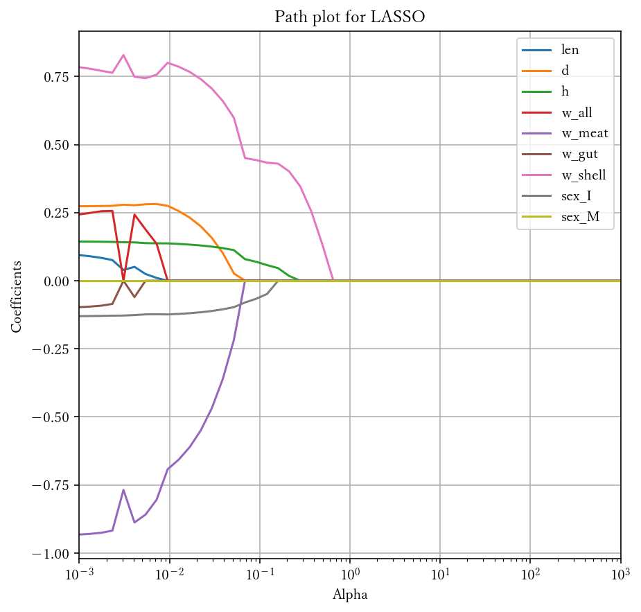

```python
ret = []
for al in alphas:
    r = model.fit_regularized(L1_wt=1.0, alpha=al)
    ret.append(r.params)

df_ret = pd.DataFrame(ret, columns=dfX_scaled.columns, index=alphas)
display(df_ret.head())  # debug
df_ret.plot(figsize=(7,7))
plt.title('Path plot for LASSO')
plt.xlabel('Alpha')
plt.ylabel('Coefficients')
plt.xscale("log")
plt.grid(True)
```

##### Elastic Net

|  | len | d | h | w_all | w_meat | w_gut | w_shell | sex_I | sex_M |
| --- | --- | --- | --- | --- | --- | --- | --- | --- | --- |
| 0.001000 | 0.099398 | 0.272662 | 0.144450 | 0.235320 | -0.931418 | -0.100600 | 0.789437 | -0.130908 | 0.0 |
| 0.001326 | 0.096956 | 0.272692 | 0.144497 | 0.239985 | -0.929151 | -0.100218 | 0.784599 | -0.130679 | 0.0 |
| 0.001758 | 0.093921 | 0.272682 | 0.144596 | 0.247881 | -0.926738 | -0.100411 | 0.777548 | -0.130365 | 0.0 |
| 0.002330 | 0.089593 | 0.272690 | 0.144651 | 0.254516 | -0.922179 | -0.099262 | 0.769694 | -0.129974 | 0.0 |
| 0.003089 | 0.083617 | 0.272680 | 0.144670 | 0.258152 | -0.914078 | -0.096187 | 0.761248 | -0.129492 | 0.0 |

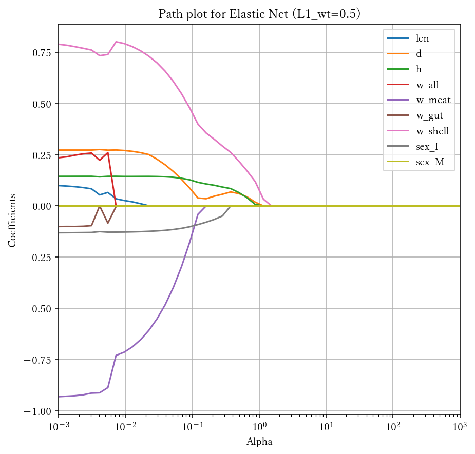

```python
ret = []
for al in alphas:
    r = model.fit_regularized(L1_wt=0.5, alpha=al)
    ret.append(r.params)

df_ret = pd.DataFrame(ret, columns=dfX_scaled.columns, index=alphas)
display(df_ret.head())  # debug
df_ret.plot(figsize=(7,7))
plt.title('Path plot for Elastic Net (L1_wt=0.5)')
plt.xlabel('Alpha')
plt.ylabel('Coefficients')
plt.xscale("log")
plt.grid(True)
```